# Aula 5: EDA - Part 2: um exemplo maior e mais comentado

```r
install.packages("tidyverse")
install.packages("here")
install.packages("dplyr")
```

```
Error in install.packages : Updating loaded packages
```

```r
library(tidyverse)
library(here)
library(dplyr)
theme_set(theme_bw())
```

#Exploracao de clima de Joao Pessoa e Campina Grande

Os dados estao disponveis em tempo.inmet.gov.br

Sao dados metereologicos de Campina Grande e Joao Pessoa

Criar a tabela a partir do csv e dos dados Lendoo scv…

```r
#Usar sempre read_csv pois há algumas facilidades. Nuc ca usar read.csv
clima = read_csv(here("data/clima_cg_jp-semanal.csv"), col_types = cols(
    cidade = col_character(),
    semana = col_datetime(format = ""),
    tmedia = col_double(),
    tmax = col_double(),
    tmin = col_double(),
    chuva = col_double()
))
```

dando uma olhada no que temos de colunas

```r
glimpse(clima)
```

```
Rows: 2,748
Columns: 6
$ cidade <chr> "Campina Grande", "Campina Grande", "Campina …
$ semana <dttm> 1992-12-27, 1993-01-03, 1993-01-10, 1993-01-…
$ tmedia <dbl> 26.13333, 26.11905, 25.76667, 25.74000, 26.31…
$ tmax   <dbl> 30.4, 32.4, 32.2, 32.0, 32.7, 32.7, 32.3, 32.…
$ tmin   <dbl> 20.7, 19.3, 19.7, 19.9, 19.6, 20.0, 20.4, 21.…
$ chuva  <dbl> 0.0, 0.0, 0.0, 0.4, 0.3, 0.0, 4.9, 0.0, 0.0, …
```

Quantas medicoes de cada cidade?

```r
clima %>%
  count(cidade)
```

| cidade | n |
| --- | --- |
| Campina Grande | 1224 |
| João Pessoa | 1524 |

Vamos reduzir os valores para apenas o ano 2000 para melhor visualizar

```r
clima = clima %>%
  slice(grep("^2000", semana))
```

A cidade é quente? o que é quente? O que diz isso é a temperatura máxima? Como se comparam as temperaturas médias das duas cidades? (As perguntas sao mais se algo varia, ou se exitesm valores repetidos, tipicos, comuns… )

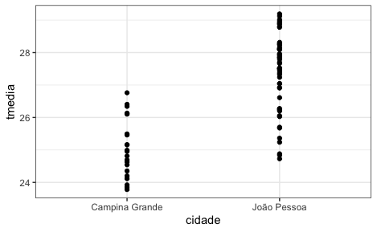

```r
clima %>%
  ggplot(mapping = aes(x = cidade, y = tmedia)) +
  geom_point()
```

DICAS: Como melhorar a visualizacao em estética

Definindo labels Mudar o alpha para ver melhor os pontos (Transparencia) Substituir o ponto para evitar sobreposicao com o jitter para ter melhor leitura

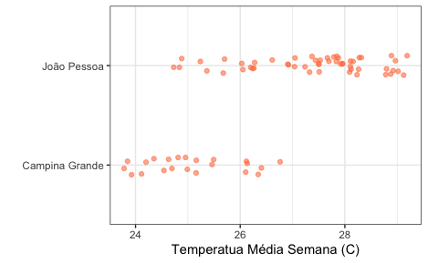

```r
clima %>%
  ggplot(mapping = aes(y = cidade, x = tmedia)) +
  geom_jitter(height = .1, alpha = .6, color = "coral") +
  labs(
    y = "",
    x = "Temperatua Média Semana (C)"
  )
```

Ao criar a melhoria ajuda mais na visualizacao para poder melhor enxergar vairacao, nao é apenas estetica mais liberdade

Algumas observacoes: Padroes: Posicoes dos valores (temperatura media) Variacao (Faixa de valores dos dados) Espalhamento / Concentracao dos pontos Pontos Extremos (Outliers (Pode ter vários significasod, entao tomar cuidado ao usar essa palavra))

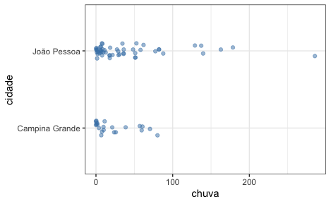

```r
clima %>%
  ggplot(mapping = aes(y = cidade, x = chuva)) +
  geom_jitter(height = .1, color = "steelblue", alpha = .5)
```

```r
NA
```

Os valores entre temperatura e chuva sao bem differentes. O espalhamento é diferente, na temperatura é mais uniforme, ja na chuva se concentra no valor minimo de chuva

Criando um histograma

(bin: dividindo os dados nessa largura) Isso mostra onde está a concentracao de pontos de chuva, e a medida que muda o valor do bin será entendido melhor a distribuicao dos pontos. Para ver melhor separamos por cidade.

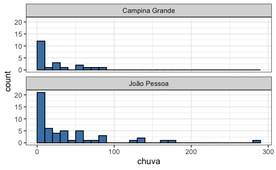

Podemos ver o número de semanas que chove menos de 10ml é bem grande.

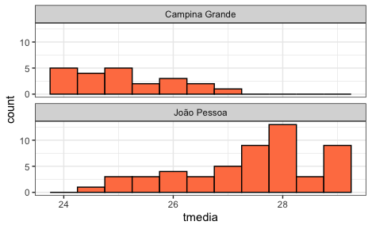

Podemos comparar, ja que o histograma possibilita uma melhor visualizacao, a distribuicao da temperatura difere entre as cidades.

Pontos que podem ser observados

SIMETRIA / ASSIMETRIA CAUDA

Caso estivesse separado por meses poderiamos ver um sumário utilizando o seguinte código. Ou sejam ver a distrobuicao mes a mes, e se também quisersemos poderia ter usado a variável ano.

clima_tudo %>% filter(cidade == “Campina Grande”, !is.na(semana)) %>% ggplot(aes(x = tmedia)) + facet_wrap(~ mes) + geom_histogram(binwidth = .5, fill = “coral”, color = “black”)

Como estimar a probabilidade de um determinado valor acontecer em uma variável. E criar uma visualizacao.

clima_tudo %>% filter(cidade == “Campina Grande”, !is.na(semana)) %>% ggplot(aes(x = tmedia)) + facet_wrap(~ mes) + geom_density( fill = “coral”, color = “black”)

Criar uma estatistica suavizada para visualizar distribuicao, permitindo comparacao entre as diferente distribuicoes.